# A/B Testing on Ad campaign

Balaji Adithya Dhandapani Shanmugasundaram

2023-08-12

# Load necessary libraries and reading csv

```r
library(readxl)
library(ggplot2)
library(dplyr)
library(tidyverse)
library(ggpubr)
library(car)
library(DescTools)
library(lmtest)
```

# Data Preprocessing

View dataset structure

```r
data <- read_csv("AB-Testing-on-Web-Analytics-Data/Data Files/marketing_AB.csv")
glimpse(data)
```

```
## Rows: 588,101
## Columns: 7
## $ ...1            <dbl> 0, 1, 2, 3, 4, 5, 6, 7, 8, 9, 10, 11, 12, 13, 14, 15, …
## $ `user id`       <dbl> 1069124, 1119715, 1144181, 1435133, 1015700, 1137664, …
## $ `test group`    <chr> "ad", "ad", "ad", "ad", "ad", "ad", "ad", "ad", "ad", …
## $ converted       <lgl> FALSE, FALSE, FALSE, FALSE, FALSE, FALSE, FALSE, FALSE…
## $ `total ads`     <dbl> 130, 93, 21, 355, 276, 734, 264, 17, 21, 142, 209, 47,…
## $ `most ads day`  <chr> "Monday", "Tuesday", "Tuesday", "Tuesday", "Friday", "…
## $ `most ads hour` <dbl> 20, 22, 18, 10, 14, 10, 13, 18, 19, 14, 11, 13, 20, 13…
```

Dropping, renaming and converting columns

```r
#Dropping
data <- data %>% select(-c(`...1`, `user id`))

#Renaming
colnames(data) <- c("test_group", "converted", "total_ads", "most_ads_day", "most_ads_hour")

#Converting data type
data$converted <- ifelse(data$converted == 'TRUE', 1, 0)
data$test_group <- as.factor(data$test_group)
data$most_ads_hour <- as.factor(data$most_ads_hour)
data$most_ads_day <- as.factor(data$most_ads_day)
#data$converted <- as.factor(data$converted) # mutating converted to 0,1
```

Checking empty values

```r
colSums(is.na(data))
```

```
##    test_group     converted     total_ads  most_ads_day most_ads_hour
##             0             0             0             0             0
```

# EDA

```r
ulst <- lapply(data, unique)
ulst
```

```
## $test_group
## [1] ad  psa
## Levels: ad psa
##
## $converted
## [1] 0 1
##
## $total_ads
##   [1]  130   93   21  355  276  734  264   17  142  209   47   61   40   20    9
##  [16]   64   26  248   73  281  389  136   87   46    3  114  175  119  313   89
##  [31]  364   24  112   49   27  274   45  177   90  265   71   31  588   56  108
##  [46]  103  239   63   66  111   74   14  258 1057  137  131  124   13   37  738
##  [61]  199  211   98   19  127   18  126  197   77   60   95   97   22  117   41
##  [76]   57  593   28   85   53   43  133   33 1328    7    6   62  247  464   99
##  [91]  233  139  407  323   76  395  166   34  246  653  122   32  386   44  138
```

[output cut: 55 more lines]

```r
summary(data)
```

```
##  test_group     converted         total_ads          most_ads_day
##  ad :564577   Min.   :0.00000   Min.   :   1.00   Friday   :92608
##  psa: 23524   1st Qu.:0.00000   1st Qu.:   4.00   Monday   :87073
##               Median :0.00000   Median :  13.00   Saturday :81660
##               Mean   :0.02524   Mean   :  24.82   Sunday   :85391
##               3rd Qu.:0.00000   3rd Qu.:  27.00   Thursday :82982
##               Max.   :1.00000   Max.   :2065.00   Tuesday  :77479
##                                                   Wednesday:80908
##  most_ads_hour
##  13     : 47655
##  12     : 47298
##  11     : 46210
##  14     : 45648
##  15     : 44683
##  10     : 38939
##  (Other):317668
```

Comparing conversion rates between the two classes of feature:converted

```r
data$converted <- as.numeric(data$converted) # mutating converted to 0,1
# Conversion rates by test group
conversion_rates <- data %>%
  group_by(test_group) %>%
  summarise(
    total_count = n(),
    converted_count = sum(converted),
    conversion_rate = (converted_count / total_count) * 100
  )

print(conversion_rates)
```

```
## # A tibble: 2 × 4
##   test_group total_count converted_count conversion_rate
##   <fct>            <int>           <dbl>           <dbl>
## 1 ad              564577           14423            2.55
## 2 psa              23524             420            1.79
```

**Observation:** The conversion rates are 2.55% and 1.79% for ad and psa classes respectively.

Comparing Distribution of Total Ads by Test Group

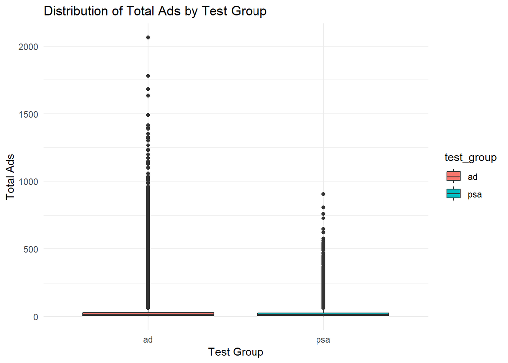

```r
ggplot(data, aes(x = test_group, y = total_ads, fill = test_group)) +
  geom_boxplot() +
  labs(title = "Distribution of Total Ads by Test Group", x = "Test Group", y = "Total Ads") +
  theme_minimal()
```

**Observation:** Both distributions(for ad and psa) are highly right-skewed. The bulk of the data for both groups appears to be concentrated in the lower range (close to 0).

Comparing Most Ads Served by Day by Test Group

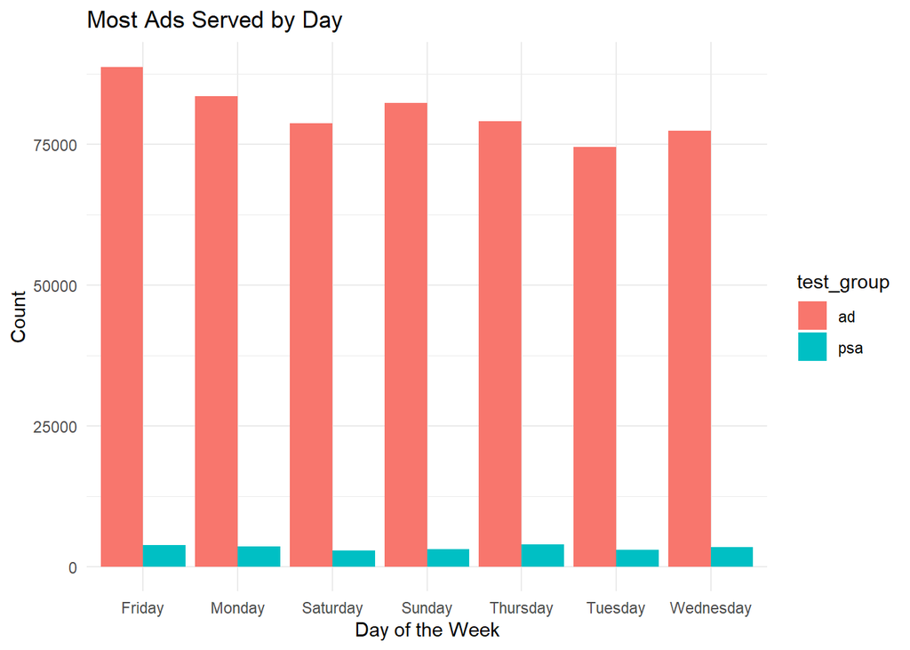

```r
ggplot(data, aes(x = most_ads_day, fill = test_group)) +
  geom_bar(position = "dodge") +
  labs(title = "Most Ads Served by Day", x = "Day of the Week", y = "Count") +
  theme_minimal()
```

**Observation:** The trend of most ads served by day differs between the two groups.

Comparing Most Ads Served by Test Group

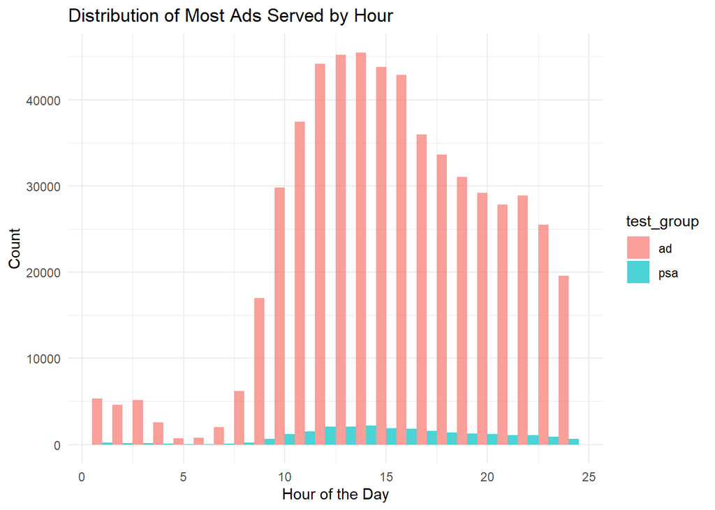

```r
data$most_ads_hour <- as.numeric(data$most_ads_hour)
ggplot(data, aes(x = most_ads_hour, fill = test_group)) +
  geom_histogram(binwidth = 1, alpha = 0.7, position = "dodge") +
  labs(title = "Distribution of Most Ads Served by Hour", x = "Hour of the Day", y = "Count") +
  theme_minimal()
```

**Observation:** The trend of most ads served by hours is similar among the two groups.

# Tests

## Chi-squared test

```r
# Create a contingency table of conversions by test group
conversion_table <- table(data$test_group, data$converted)
print(conversion_table)
```

```
##
##            0      1
##   ad  550154  14423
##   psa  23104    420
```

```r
# Perform the Chi-Squared test
chi_test_result <- chisq.test(conversion_table, correct = FALSE)
print(chi_test_result)
```

```
##
##  Pearson's Chi-squared test
##
## data:  conversion_table
## X-squared = 54.318, df = 1, p-value = 1.705e-13
```

**Interpretation:** X-squared = 54.318, df = 1, p-value = 1.705e-13. As p<0.05 (Significance level), we can conclude that the variables test_group and converted are dependent, thereby there exists significant difference between the conversion rates between the two groups.

But we have to test for interaction between other features. Let us fit a logistic model to ascertain if there exists an interaction.

### LogReg: Base model

```r
logit_model_no_interaction <- glm(converted ~ test_group + total_ads + most_ads_day + most_ads_hour,
                                   data = data, family = binomial())

summary(logit_model_no_interaction)  # Check significance of coefficients
```

```
##
## Call:
## glm(formula = converted ~ test_group + total_ads + most_ads_day +
##     most_ads_hour, family = binomial(), data = data)
##
## Coefficients:
##                         Estimate Std. Error  z value Pr(>|z|)
## (Intercept)           -4.795e+00  3.902e-02 -122.896  < 2e-16 ***
## test_grouppsa         -3.779e-01  5.153e-02   -7.332 2.26e-13 ***
## total_ads              1.027e-02  9.922e-05  103.496  < 2e-16 ***
## most_ads_dayMonday     4.725e-01  3.066e-02   15.410  < 2e-16 ***
## most_ads_daySaturday   2.196e-02  3.432e-02    0.640   0.5223
## most_ads_daySunday     2.174e-01  3.260e-02    6.668 2.60e-11 ***
## most_ads_dayThursday   6.794e-02  3.402e-02    1.997   0.0459 *
## most_ads_dayTuesday    4.438e-01  3.197e-02   13.880  < 2e-16 ***
## most_ads_dayWednesday  2.087e-01  3.313e-02    6.301 2.95e-10 ***
## most_ads_hour          3.371e-02  1.838e-03   18.342  < 2e-16 ***
## ---
## Signif. codes:  0 '***' 0.001 '**' 0.01 '*' 0.05 '.' 0.1 ' ' 1
##
## (Dispersion parameter for binomial family taken to be 1)
##
##     Null deviance: 138534  on 588100  degrees of freedom
## Residual deviance: 127416  on 588091  degrees of freedom
## AIC: 127436
##
## Number of Fisher Scoring iterations: 6
```

```r
exp(coef(logit_model_no_interaction))
```

```
##           (Intercept)         test_grouppsa             total_ads
##           0.008270835           0.685331583           1.010321885
##    most_ads_dayMonday  most_ads_daySaturday    most_ads_daySunday
##           1.603973955           1.022200912           1.242781337
##  most_ads_dayThursday   most_ads_dayTuesday most_ads_dayWednesday
##           1.070295793           1.558564978           1.232135775
##         most_ads_hour
##           1.034284134
```

**Interpretation:**

1. Intercept = -4.795e+00, as it is negative, the baseline conversion probability is low.
2. coefficient of test_grouppsa = -3.779e-01, The psa test group has a lower conversion rate compared to the ad group. psa has a 0.68 times lower conversion than ad.
3. coefficient of total_ads =1.027e-02, each additional ad exposure increases the odds of conversion as value is postive. Percentage Change=(Odds Ratio−1)×100 = 1.03. Therefore, meaning each additional ad increases conversion odds by 1.03%.

   ```r
   pct_change = (1.010321885-1)*100
   print(pct_change)
   ```

   ```
   ## [1] 1.032188
   ```

4. Ads on Monday and Tuesday have the highest conversion rates (as highest odds ratio), while Saturday has no significant effect.

### 1. LogReg: Base model + test_group and total_ads interaction

```r
logit_model_int_INTtest_groupANDtotal_ads <- glm(converted ~ test_group + total_ads + most_ads_day + most_ads_hour + test_group:total_ads, # Interaction term
                   data = data, family = binomial())

summary(logit_model_int_INTtest_groupANDtotal_ads)  # Check significance of coefficients
```

```
##
## Call:
## glm(formula = converted ~ test_group + total_ads + most_ads_day +
##     most_ads_hour + test_group:total_ads, family = binomial(),
##     data = data)
##
## Coefficients:
##                           Estimate Std. Error  z value Pr(>|z|)
## (Intercept)             -4.7960818  0.0390385 -122.855  < 2e-16 ***
## test_grouppsa           -0.3509182  0.0598724   -5.861 4.60e-09 ***
## total_ads                0.0102858  0.0001011  101.692  < 2e-16 ***
## most_ads_dayMonday       0.4725790  0.0306627   15.412  < 2e-16 ***
## most_ads_daySaturday     0.0221774  0.0343249    0.646   0.5182
## most_ads_daySunday       0.2173939  0.0325983    6.669 2.58e-11 ***
## most_ads_dayThursday     0.0681708  0.0340250    2.004   0.0451 *
## most_ads_dayTuesday      0.4437604  0.0319726   13.879  < 2e-16 ***
## most_ads_dayWednesday    0.2086968  0.0331285    6.300 2.98e-10 ***
## most_ads_hour            0.0337161  0.0018379   18.344  < 2e-16 ***
## test_grouppsa:total_ads -0.0004502  0.0005209   -0.864   0.3875
## ---
## Signif. codes:  0 '***' 0.001 '**' 0.01 '*' 0.05 '.' 0.1 ' ' 1
##
## (Dispersion parameter for binomial family taken to be 1)
##
##     Null deviance: 138534  on 588100  degrees of freedom
## Residual deviance: 127416  on 588090  degrees of freedom
## AIC: 127438
##
## Number of Fisher Scoring iterations: 6
```

```r
exp(coef(logit_model_int_INTtest_groupANDtotal_ads))  # Get odds ratios
```

```
##             (Intercept)           test_grouppsa               total_ads
##             0.008262056             0.704041337             1.010338917
##      most_ads_dayMonday    most_ads_daySaturday      most_ads_daySunday
##             1.604125901             1.022425155             1.242833508
##    most_ads_dayThursday     most_ads_dayTuesday   most_ads_dayWednesday
##             1.070548126             1.558556999             1.232071341
##           most_ads_hour test_grouppsa:total_ads
##             1.034290902             0.999549928
```

```r
# Compare models with and without interaction terms
lrtest(logit_model_int_INTtest_groupANDtotal_ads, logit_model_no_interaction)
```

```
## Likelihood ratio test
##
## Model 1: converted ~ test_group + total_ads + most_ads_day + most_ads_hour +
##     test_group:total_ads
## Model 2: converted ~ test_group + total_ads + most_ads_day + most_ads_hour
##   #Df LogLik Df  Chisq Pr(>Chisq)
## 1  11 -63708
## 2  10 -63708 -1 0.7463     0.3876
```

**Interpretation:** Both models have the same log-likelihood, meaning adding the interaction term did not improve model fit. The p-value is greater than significance level, meaning that the interaction term is not significant.

### 2. LogReg: Base model + test_group and most_ads_day interaction

```r
logit_model_int_INTtest_groupANDmost_ads_day <- glm(converted ~ test_group + total_ads + most_ads_day + most_ads_hour + test_group:most_ads_day, # Interaction term
                                                 data = data, family = binomial())
summary(logit_model_int_INTtest_groupANDmost_ads_day)  # Check significance of coefficients
```

```
##
## Call:
## glm(formula = converted ~ test_group + total_ads + most_ads_day +
##     most_ads_hour + test_group:most_ads_day, family = binomial(),
##     data = data)
##
## Coefficients:
##                                       Estimate Std. Error  z value Pr(>|z|)
## (Intercept)                         -4.798e+00  3.923e-02 -122.305  < 2e-16 ***
## test_grouppsa                       -2.952e-01  1.351e-01   -2.185   0.0289 *
## total_ads                            1.027e-02  9.924e-05  103.464  < 2e-16 ***
## most_ads_dayMonday                   4.758e-01  3.113e-02   15.286  < 2e-16 ***
## most_ads_daySaturday                 2.784e-02  3.479e-02    0.800   0.4236
## most_ads_daySunday                   2.144e-01  3.311e-02    6.477 9.37e-11 ***
## most_ads_dayThursday                 6.117e-02  3.468e-02    1.764   0.0778 .
## most_ads_dayTuesday                  4.538e-01  3.238e-02   14.014  < 2e-16 ***
## most_ads_dayWednesday                2.144e-01  3.363e-02    6.376 1.81e-10 ***
## most_ads_hour                        3.372e-02  1.838e-03   18.346  < 2e-16 ***
## test_grouppsa:most_ads_dayMonday    -1.138e-01  1.806e-01   -0.630   0.5285
## test_grouppsa:most_ads_daySaturday  -2.213e-01  2.141e-01   -1.033   0.3014
## test_grouppsa:most_ads_daySunday     1.073e-01  1.883e-01    0.570   0.5688
## test_grouppsa:most_ads_dayThursday   1.518e-01  1.814e-01    0.837   0.4028
## test_grouppsa:most_ads_dayTuesday   -4.282e-01  2.092e-01   -2.046   0.0407 *
## test_grouppsa:most_ads_dayWednesday -1.922e-01  1.961e-01   -0.980   0.3270
## ---
## Signif. codes:  0 '***' 0.001 '**' 0.01 '*' 0.05 '.' 0.1 ' ' 1
##
## (Dispersion parameter for binomial family taken to be 1)
##
##     Null deviance: 138534  on 588100  degrees of freedom
## Residual deviance: 127404  on 588085  degrees of freedom
## AIC: 127436
##
## Number of Fisher Scoring iterations: 6
```

```r
exp(coef(logit_model_int_INTtest_groupANDmost_ads_day))  # Get odds ratios
```

```
##                         (Intercept)                       test_grouppsa
##                         0.008250136                         0.744395308
##                           total_ads                  most_ads_dayMonday
##                         1.010320309                         1.609326876
##                most_ads_daySaturday                  most_ads_daySunday
##                         1.028233118                         1.239159390
##                most_ads_dayThursday                 most_ads_dayTuesday
##                         1.063079583                         1.574304923
##               most_ads_dayWednesday                       most_ads_hour
##                         1.239126714                         1.034293130
##    test_grouppsa:most_ads_dayMonday  test_grouppsa:most_ads_daySaturday
##                         0.892426193                         0.801480664
##    test_grouppsa:most_ads_daySunday  test_grouppsa:most_ads_dayThursday
##                         1.113302328                         1.163921675
##   test_grouppsa:most_ads_dayTuesday test_grouppsa:most_ads_dayWednesday
##                         0.651713537                         0.825167087
```

```r
# Compare models with and without interaction terms lrtest
lrtest(logit_model_int_INTtest_groupANDmost_ads_day, logit_model_no_interaction)
```

```
## Likelihood ratio test
##
## Model 1: converted ~ test_group + total_ads + most_ads_day + most_ads_hour +
##     test_group:most_ads_day
## Model 2: converted ~ test_group + total_ads + most_ads_day + most_ads_hour
##   #Df LogLik Df  Chisq Pr(>Chisq)
## 1  16 -63702
## 2  10 -63708 -6 12.469    0.05229 .
## ---
## Signif. codes:  0 '***' 0.001 '**' 0.01 '*' 0.05 '.' 0.1 ' ' 1
```

**Interpretation:** The model with the interaction term has higher log-likelihood, meaning adding the interaction term improved model fit. But the p-value is greater than significance level, meaning that the interaction term is not significant.

Most interactions are not significant, meaning the effect of most_ads_day is similar across ad and psa groups except for Tuesday. Tuesday had significant negative interaction, meaning that on Tuesdays, the PSA group has significantly lower conversions compared to the AD group.

```r
logit_model_int_INTtest_groupANDmost_ads_hour <- glm(converted ~ test_group + total_ads + most_ads_day + most_ads_hour + test_group:most_ads_hour, # Interaction term
                                                 data = data, family = binomial())
summary(logit_model_int_INTtest_groupANDmost_ads_hour)  # Check significance of coefficients
```

```
##
## Call:
## glm(formula = converted ~ test_group + total_ads + most_ads_day +
##     most_ads_hour + test_group:most_ads_hour, family = binomial(),
##     data = data)
##
## Coefficients:
##                               Estimate Std. Error  z value Pr(>|z|)
## (Intercept)                 -4.785e+00  3.931e-02 -121.735  < 2e-16 ***
## test_grouppsa               -7.439e-01  1.958e-01   -3.798 0.000146 ***
## total_ads                    1.027e-02  9.924e-05  103.480  < 2e-16 ***
## most_ads_dayMonday           4.724e-01  3.067e-02   15.404  < 2e-16 ***
## most_ads_daySaturday         2.193e-02  3.433e-02    0.639 0.522944
## most_ads_daySunday           2.171e-01  3.260e-02    6.660 2.74e-11 ***
## most_ads_dayThursday         6.789e-02  3.403e-02    1.995 0.046050 *
## most_ads_dayTuesday          4.437e-01  3.198e-02   13.877  < 2e-16 ***
## most_ads_dayWednesday        2.080e-01  3.313e-02    6.278 3.43e-10 ***
## most_ads_hour                3.312e-02  1.862e-03   17.784  < 2e-16 ***
## test_grouppsa:most_ads_hour  2.271e-02  1.158e-02    1.961 0.049850 *
## ---
## Signif. codes:  0 '***' 0.001 '**' 0.01 '*' 0.05 '.' 0.1 ' ' 1
##
## (Dispersion parameter for binomial family taken to be 1)
##
##     Null deviance: 138534  on 588100  degrees of freedom
## Residual deviance: 127412  on 588090  degrees of freedom
## AIC: 127434
##
## Number of Fisher Scoring iterations: 7
```

```r
exp(coef(logit_model_int_INTtest_groupANDmost_ads_hour))  # Get odds ratios
```

```
##                 (Intercept)               test_grouppsa
##                   0.0083518                   0.4752642
##                   total_ads          most_ads_dayMonday
##                   1.0103219                   1.6037960
##        most_ads_daySaturday          most_ads_daySunday
##                   1.0221723                   1.2424850
##        most_ads_dayThursday         most_ads_dayTuesday
##                   1.0702436                   1.5585006
##       most_ads_dayWednesday               most_ads_hour
##                   1.2312355                   1.0336697
## test_grouppsa:most_ads_hour
##                   1.0229698
```

```r
# Compare models with and without interaction terms lrtest
lrtest(logit_model_int_INTtest_groupANDmost_ads_hour, logit_model_no_interaction)
```

```
## Likelihood ratio test
##
## Model 1: converted ~ test_group + total_ads + most_ads_day + most_ads_hour +
##     test_group:most_ads_hour
## Model 2: converted ~ test_group + total_ads + most_ads_day + most_ads_hour
##   #Df LogLik Df  Chisq Pr(>Chisq)
## 1  11 -63706
## 2  10 -63708 -1 3.8844    0.04874 *
## ---
## Signif. codes:  0 '***' 0.001 '**' 0.01 '*' 0.05 '.' 0.1 ' ' 1
```

**Interpretation:** The model with the interaction term has higher log-likelihood, meaning adding the interaction term improved model fit. Moreover the p-value is lesser than significance level, meaning that the interaction term is significant. The impact of the hour at which most ads are shown (most_ads_hour) on conversion is different between the ad and psa groups.

# Findings

### 1. Ad spending should be increased ad there was significant difference

The psa group has significantly lower conversion rates (52.5% less likely to convert) than the AD group.

### 2. Schedule Ads during late lours, especially for psa group

Later hours significantly increase conversions, and the PSA group benefits even more from later ad exposure.

### 3. Focus advertising efforts on Monday and Tuesday

These two days have the highest conversion rates. Allocate more budget and ad placements to these days for better performance.

### 4. Avoid running Ads on Saturdays

Saturday does not show any significant increase in conversions.

### 5. Keep the interaction term in the model

- The interaction between test_group and most_ads_hour was significant.
- This confirms that later ad exposure benefits PSA campaigns more than AD campaigns.